# Session 3 Uncertainty visualizations

Xiaoying Pu, Lace Padilla

3/3/2022

## Dataset 1 Blinded with Science

### Load the data

```r
(df1 <- read_csv("data/blinded.csv") %>%
  filter(experiment == 1) %>%
  mutate(
    condition = factor(condition),
    participant_id = paste0("P", str_pad(row_number(), 2, pad = "0")))
)
```

```
## # A tibble: 123 × 4
##    experiment condition effectiveness participant_id
##         <dbl> <fct>             <dbl> <chr>
##  1          1 no_graph              7 P01
##  2          1 graph                 6 P02
##  3          1 no_graph              9 P03
##  4          1 no_graph              4 P04
##  5          1 graph                 6 P05
##  6          1 no_graph              7 P06
##  7          1 graph                 7 P07
##  8          1 no_graph              7 P08
##  9          1 no_graph              7 P09
## 10          1 graph                 6 P10
## # … with 113 more rows
```

### Explore the data with ggplot

We modeled how `condition` (graph or no graph) affected `effectiveness`, a Likert scale rating from 1 to 9.

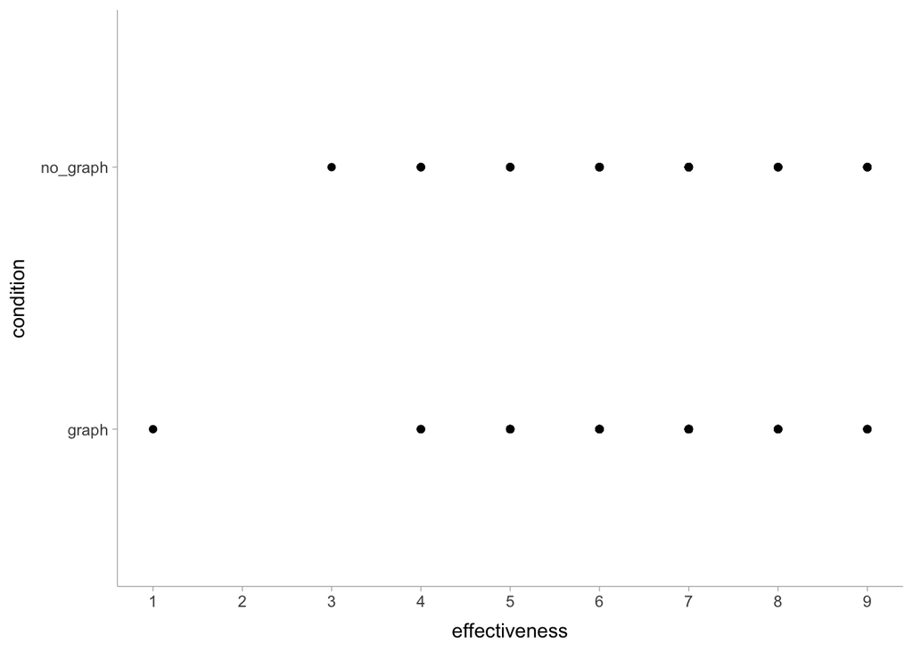

```r
df1 %>%
  ggplot(aes(
    x = effectiveness,
    y = condition)) +  # EXERCISE: add color
  geom_point() +       # EXERCISE: change to jitter
  scale_x_continuous(breaks = 1:9)
```

Alternative: try aggregation

```r
df1 %>%
  count(effectiveness, condition, name = "n") %>%
  pivot_wider(names_from = condition, values_from = n, values_fill = 0)
```

```
## # A tibble: 8 × 3
##   effectiveness graph no_graph
##           <dbl> <int>    <int>
## 1             1     1        0
## 2             3     0        1
## 3             4     3        4
## 4             5     8        5
## 5             6    14       12
## 6             7    21       25
## 7             8     9        7
## 8             9     5        8
```

Visualize the aggregated dataset

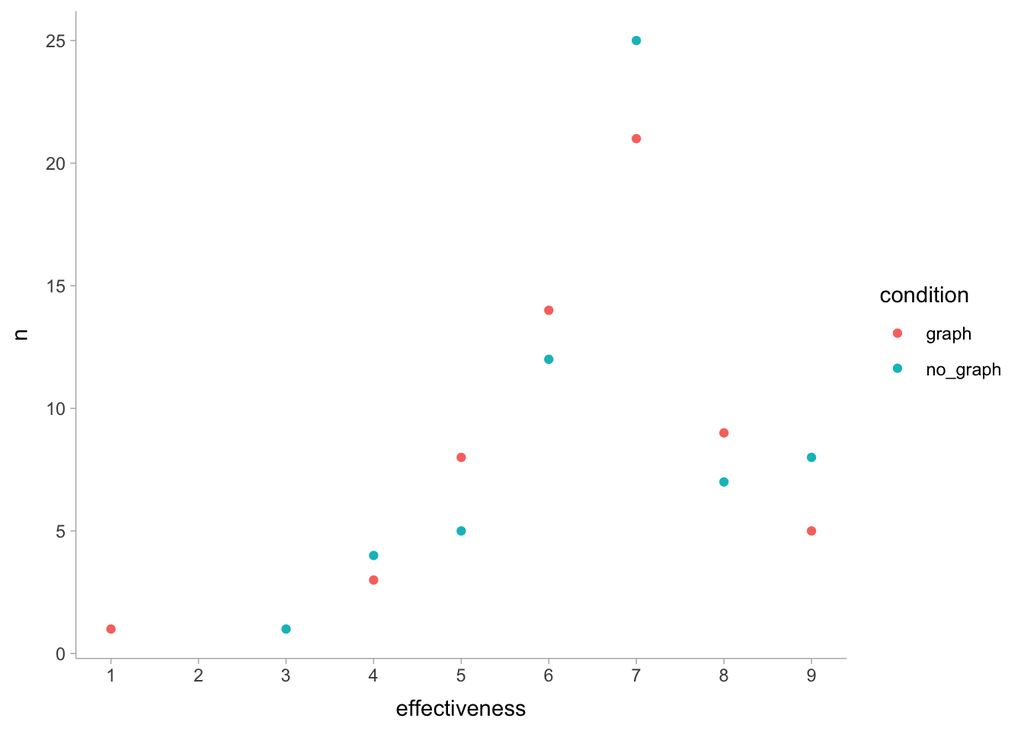

```r
df1 %>%
  count(condition, effectiveness, name = "n") %>%
  ggplot(aes(x = effectiveness, y = n, color = condition)) +
  geom_point() +     # EXERCISE: change to line chart (geom_line)
  # EXERCISE: point + line??
  scale_x_continuous(breaks = 1:9)
```

## Dataset 1, frequentist land

### Wilcoxon

```r
m_wilcox <- wilcox.test(
    effectiveness ~ condition,
    data = df1, paired = FALSE, conf.int = TRUE)

tidy(m_wilcox)
```

```
## # A tibble: 1 × 7
##     estimate statistic p.value conf.low conf.high method             alternative
##        <dbl>     <dbl>   <dbl>    <dbl>     <dbl> <chr>              <chr>
## 1 -0.0000392      1762   0.501    -1.00 0.0000355 Wilcoxon rank sum… two.sided
```

Reflection: is this interval surprising? Is this useful?

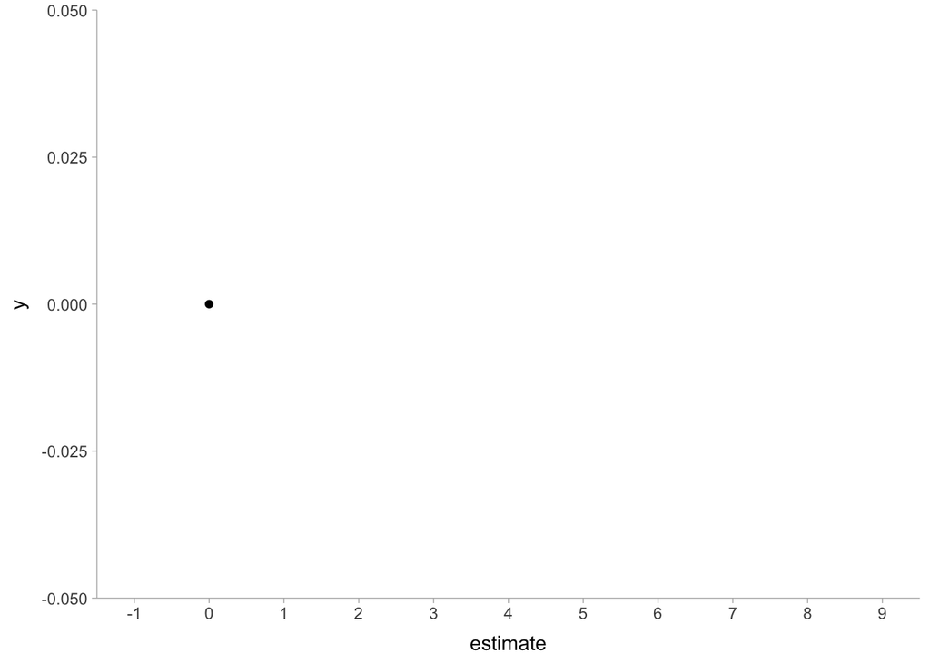

```r
tidy(m_wilcox) %>%
  ggplot(aes(x = estimate, y = 0)) +
  geom_point() +
  # EXERCISE: add intervals
  # geom_pointinterval(aes(xmin = conf.low, xmax = conf.high)) +
  scale_x_continuous(breaks = -1:9, limits = c(-1, 9))
```

### t-test

Baseline: table/textual reporting

```r
m_t_test <- t.test(
  effectiveness ~ condition,
  data = df1, paired = FALSE, conf.int = TRUE)
```

```r
m_t_test
```

```
##
##  Welch Two Sample t-test
##
## data:  effectiveness by condition
## t = -0.71606, df = 120.63, p-value = 0.4753
## alternative hypothesis: true difference in means between group graph and group no_graph is not equal to 0
## 95 percent confidence interval:
##  -0.6938441  0.3252560
## sample estimates:
##    mean in group graph mean in group no_graph
##               6.573770               6.758065
```

t-test is equivalent to a linear model with a slope and intercept $y_i = \beta_0 + \beta_1 x_i$ (`1 + condition` below) so using `lm` because the output is easier to wrangle (good explainer: https://lindeloev.github.io/tests-as-linear/#61_one-way_anova_and_kruskal-wallis)

```r
(m_t_test <- lm(effectiveness ~ 1 + condition, data = df1))
```

```
##
## Call:
## lm(formula = effectiveness ~ 1 + condition, data = df1)
##
## Coefficients:
##       (Intercept)  conditionno_graph
##            6.5738             0.1843
```

Tidy view of the t-test results

```r
m_t_test %>%
  tidy()
```

```
## # A tibble: 2 × 5
##   term              estimate std.error statistic  p.value
##   <chr>                <dbl>     <dbl>     <dbl>    <dbl>
## 1 (Intercept)          6.57      0.183    36.0   1.76e-66
## 2 conditionno_graph    0.184     0.257     0.716 4.75e- 1
```

Point estimates

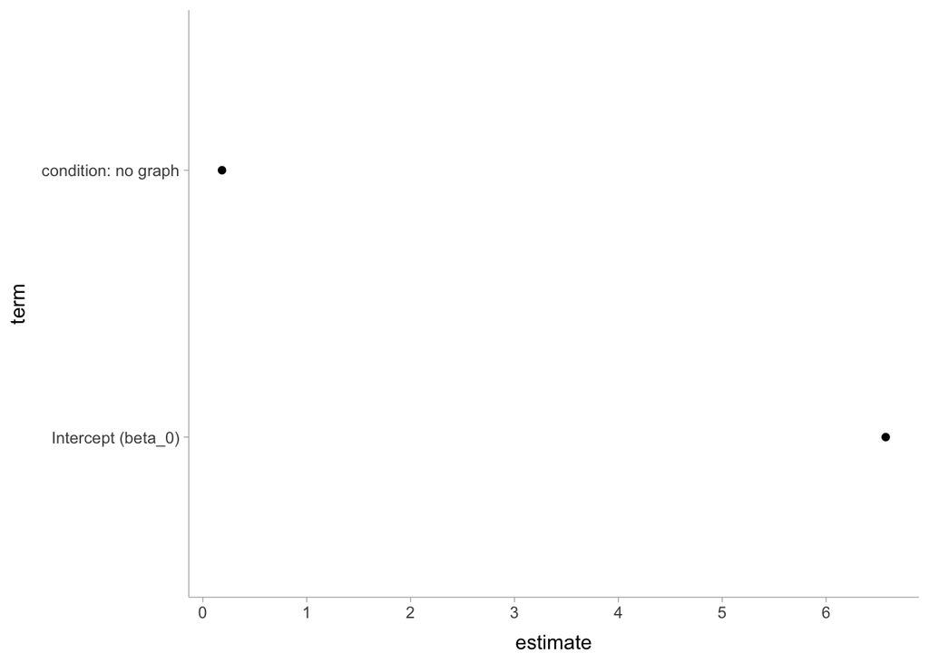

```r
tidy(m_t_test) %>%
  ggplot(aes(x = estimate, y = term)) +
  geom_point() +
  scale_x_continuous(breaks=-1:9) +
  scale_y_discrete(labels = c("Intercept (beta_0)", "condition: no graph"))
```

Add interval for uncertainty. The *confidence distribution* for the parameters follows the student-t distribution. https://mjskay.github.io/ggdist/articles/freq-uncertainty-vis.html

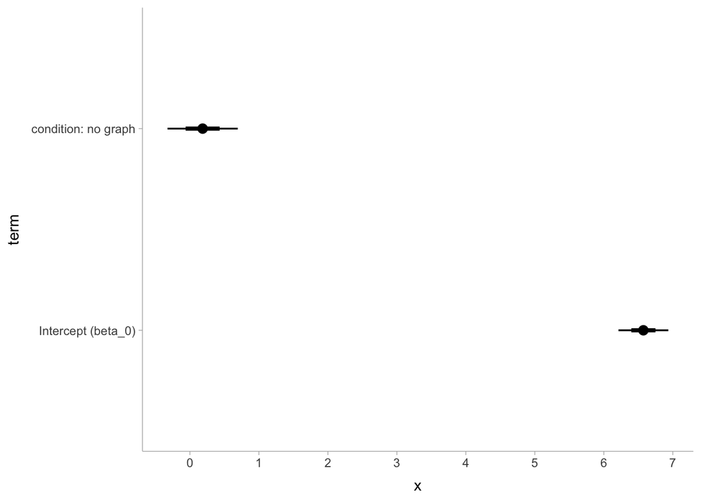

```r
tidy(m_t_test) %>%
  ggplot(aes(
    xdist = dist_student_t( # EXERCISE: what does this mean?
      df = df.residual(m_t_test),
      mu = estimate,
      sigma = std.error),
    y = term)) +
  stat_pointinterval() +
  scale_x_continuous(breaks=-1:9) +
  scale_y_discrete(labels = c("Intercept (beta_0)", "condition: no graph"))
```

That was for the paramters. Now we make predictions () with `augment`

```r
(aug_df1 <- df1 %>%
  data_grid(condition) %>%
  augment(m_t_test, newdata = ., se_fit = TRUE)
)
```

```
## # A tibble: 2 × 3
##   condition .fitted .se.fit
##   <fct>       <dbl>   <dbl>
## 1 graph        6.57   0.183
## 2 no_graph     6.76   0.181
```

EXERCISE: why are the densities so narrow? Does it make sense? What encoding do you prefer?

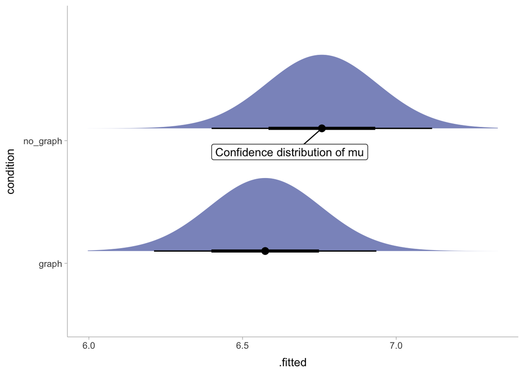

```r
aug_df1 %>%
  ggplot(aes(y = condition)) +
  # geom_jitter(            # EXERCIESE: add raw data
  #   aes(
  #     x = effectiveness,
  #     y = condition),
  #   data =df1, height = 0.05, alpha = .5) +
  stat_halfeye(             # EXERCIESE: change to stat_dots
    aes(xdist =dist_student_t(
      df = df.residual(m_t_test),
      mu = .fitted, sigma = .se.fit)),
    scale = 0.6, fill = "#8c96c6",
    position = position_nudge(y = 0.1)) +
  geom_label_repel(aes(.fitted, y = condition), data = aug_df1 %>% slice_tail(),
                   label = "Confidence distribution of mu", box.padding = 1,
                   position = position_nudge(y = 0.1), max.overlaps = Inf) +
  # geom_label_repel( # EXERCISE: add labels for the raw data
  #   aes(.fitted, y = condition),
  #   data = aug_df1 %>% slice_head(),
  #   label = "Jittered raw data", box.padding = 1,
  #   position = position_nudge_repel(y = -0.2)) +
  NULL
```

Show fit line with data

```r
(coefficients <- m_t_test %>%
  tidy() %>%
  mutate(term = c("intercept", "slope")) %>%
  select(term, estimate) %>%
  deframe()
)
```

```
## intercept     slope
##  6.573770  0.184294
```

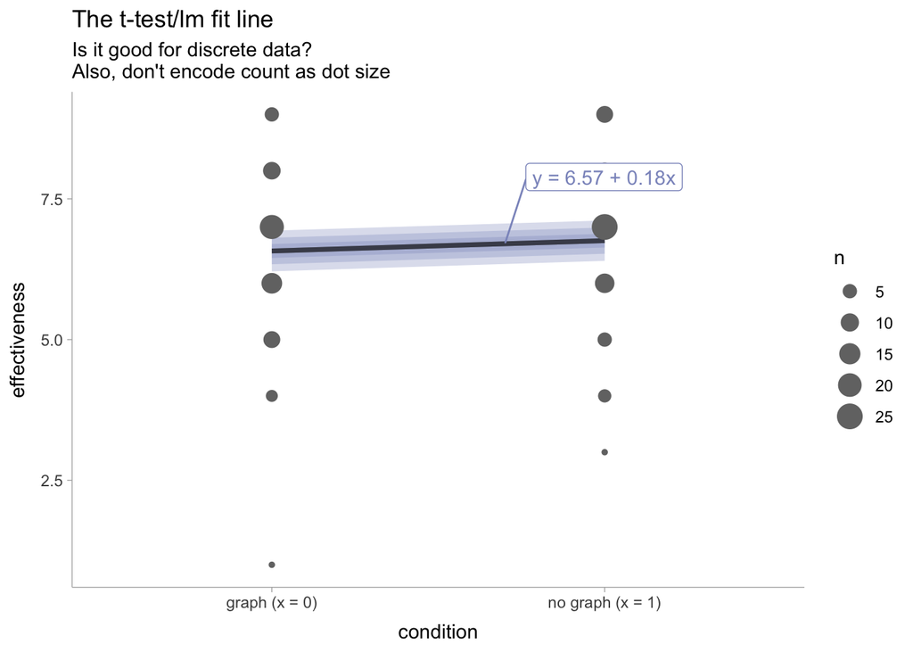

```r
df1 %>%
  ggplot(aes(x = ifelse(condition == "graph", 0, 1), y = effectiveness)) +
  stat_lineribbon(aes(
    x = ifelse(condition == "graph", 0, 1), y = NULL,
    ydist = dist_student_t(
      df = df.residual(m_t_test),
      mu = .fitted, sigma = .se.fit)),
    data = aug_df1, alpha = 0.3, fill = "#8c96c6") +
  geom_count(color = "gray45") +
  geom_label_repel(
    data = tibble(x =0.7, y = 0.7 * 0.18 + 6.57),
    mapping = aes(x = x, y = y),
    label = glue("y = {format(round(coefficients[\"intercept\"], 2), nsmall=2)} + {format(round(coefficients[\"slope\"], 2), nsmall=2)}x"), color = "#8c96c6",
    box.padding = 2) +
  labs(
    title = "The t-test/lm fit line",
    subtitle = "Is it good for discrete data?\nAlso, don't encode count as dot size") +
  xlab("condition") +
  scale_x_continuous(breaks = c(0,1), labels = c("graph (x = 0)", "no graph (x = 1)"), limits = c(-0.5, 1.5))
```

### Ordinal linear regression

https://bookdown.org/ajkurz/Statistical_Rethinking_recoded/monsters-and-mixtures.html#ordered-categorical-outcomes

We’ve seen this before

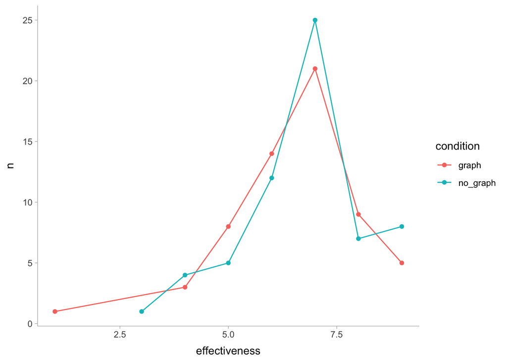

```r
df1 %>%
  count(condition, effectiveness, name = "n") %>%
  ggplot(aes(x = effectiveness, y = n, color = condition)) +
  geom_point() +
  geom_line() +
  NULL
```

Building up to the ordinal linear regression model… introducing the cumulative proportions (“odds”), and cumulative log odds (computed with `logit()`)

```r
logit <- function(x) log(x / (1 - x))

(cumu_df1 <- df1 %>%
  count(condition, effectiveness, name = "n") %>%
  add_row(condition = "graph", effectiveness = 2, n = 0) %>%
  complete(condition, effectiveness, fill = list(n = 0)) %>%
  group_by(condition) %>%
  mutate(
    pr_k = n / sum(n),
    cum_pr_k = cumsum(pr_k),
    cum_pr_k_1 = cum_pr_k - (pr_k),
    logit_cum_pr_k = logit(cum_pr_k))
)
```

```
## # A tibble: 18 × 7
## # Groups:   condition [2]
##    condition effectiveness     n   pr_k cum_pr_k cum_pr_k_1 logit_cum_pr_k
##    <chr>             <dbl> <dbl>  <dbl>    <dbl>      <dbl>          <dbl>
##  1 graph                 1     1 0.0164   0.0164     0              -4.09
##  2 graph                 2     0 0        0.0164     0.0164         -4.09
##  3 graph                 3     0 0        0.0164     0.0164         -4.09
##  4 graph                 4     3 0.0492   0.0656     0.0164         -2.66
##  5 graph                 5     8 0.131    0.197      0.0656         -1.41
##  6 graph                 6    14 0.230    0.426      0.197          -0.297
##  7 graph                 7    21 0.344    0.770      0.426           1.21
##  8 graph                 8     9 0.148    0.918      0.770           2.42
##  9 graph                 9     5 0.0820   1          0.918         Inf
## 10 no_graph              1     0 0        0          0            -Inf
## 11 no_graph              2     0 0        0          0            -Inf
## 12 no_graph              3     1 0.0161   0.0161     0              -4.11
## 13 no_graph              4     4 0.0645   0.0806     0.0161         -2.43
## 14 no_graph              5     5 0.0806   0.161      0.0806         -1.65
## 15 no_graph              6    12 0.194    0.355      0.161          -0.598
## 16 no_graph              7    25 0.403    0.758      0.355           1.14
## 17 no_graph              8     7 0.113    0.871      0.758           1.91
## 18 no_graph              9     8 0.129    1          0.871         Inf
```

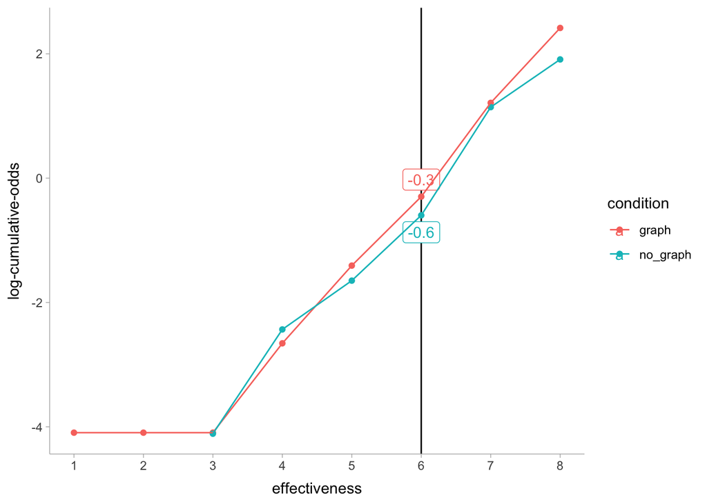

```r
cumu_df1 %>%
  filter(!is.infinite(logit_cum_pr_k)) %>%
  ggplot(aes(x = effectiveness, y = logit_cum_pr_k, color = condition, label = round(logit_cum_pr_k, 2))) +
  geom_vline(xintercept = 6) +
  geom_label_repel(data = cumu_df1 %>% filter(effectiveness == 6)) +
  geom_point() +
  geom_line() +
  scale_x_continuous(breaks = 1:9) +
  ylab("log-cumulative-odds")
```

Once we have the estimates in the cumulative log odds space, can do inverse logit (`brms::inv_logit_scaled()`), and get proportions out of the cumulative proportions.

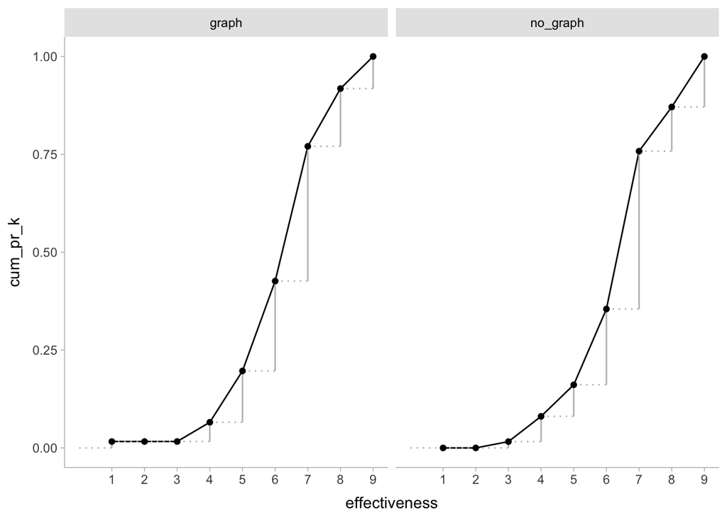

```r
cumu_df1 %>%
  ggplot(aes(x = effectiveness, y = cum_pr_k)) +
  geom_line() +
  geom_segment(aes(
    x = effectiveness,
    xend = effectiveness,
    y = cum_pr_k,
    yend = cum_pr_k_1),
    color = "grey") +
  geom_segment(aes(
    x = effectiveness - 1,
    xend = effectiveness,
    y = cum_pr_k_1,
    yend = cum_pr_k_1),
    linetype = "dotted", color = "grey") +
  geom_point() +
  scale_x_continuous(breaks = 1:9) +
  facet_grid(~condition)
```

```r
(m_olr_freq <- df1 %>%
  mutate(effectiveness = ordered(effectiveness, levels = as.character(1:9))) %>%
  ordinal::clm(effectiveness ~ condition, data = .)
)
```

```
## formula: effectiveness ~ condition
## data:    .
##
##  link  threshold nobs logLik  AIC    niter max.grad cond.H
##  logit flexible  123  -206.17 428.34 6(0)  1.30e-10 1.0e+02
##
## Coefficients:
## conditionno_graph
##            0.2196
##
## Threshold coefficients:
##     1|3     3|4     4|5     5|6     6|7     7|8     8|9
## -4.6984 -3.9970 -2.4348 -1.4189 -0.3368  1.2891  2.2494
```

```r
glance(m_olr_freq)
```

```
## # A tibble: 1 × 6
##     edf   AIC   BIC logLik    df.residual  nobs
##   <int> <dbl> <dbl> <logLik>        <dbl> <dbl>
## 1     8  428.  451. -206.1689         115   123
```

```r
tidy(m_olr_freq)
```

```
## # A tibble: 8 × 6
##   term              estimate std.error statistic  p.value coef.type
##   <chr>                <dbl>     <dbl>     <dbl>    <dbl> <chr>
## 1 1|3                 -4.70      1.02     -4.63  3.73e- 6 intercept
## 2 3|4                 -4.00      0.729    -5.48  4.20e- 8 intercept
## 3 4|5                 -2.43      0.378    -6.45  1.15e-10 intercept
## 4 5|6                 -1.42      0.281    -5.06  4.28e- 7 intercept
## 5 6|7                 -0.337     0.245    -1.38  1.69e- 1 intercept
## 6 7|8                  1.29      0.271     4.75  2.04e- 6 intercept
## 7 8|9                  2.25      0.339     6.63  3.41e-11 intercept
## 8 conditionno_graph    0.220     0.324     0.678 4.98e- 1 location
```

```r
(condition_no_graph <- tidy(m_olr_freq) %>% slice_tail())
```

```
## # A tibble: 1 × 6
##   term              estimate std.error statistic p.value coef.type
##   <chr>                <dbl>     <dbl>     <dbl>   <dbl> <chr>
## 1 conditionno_graph    0.220     0.324     0.678   0.498 location
```

Showing estimates on the cumulative log odds scale

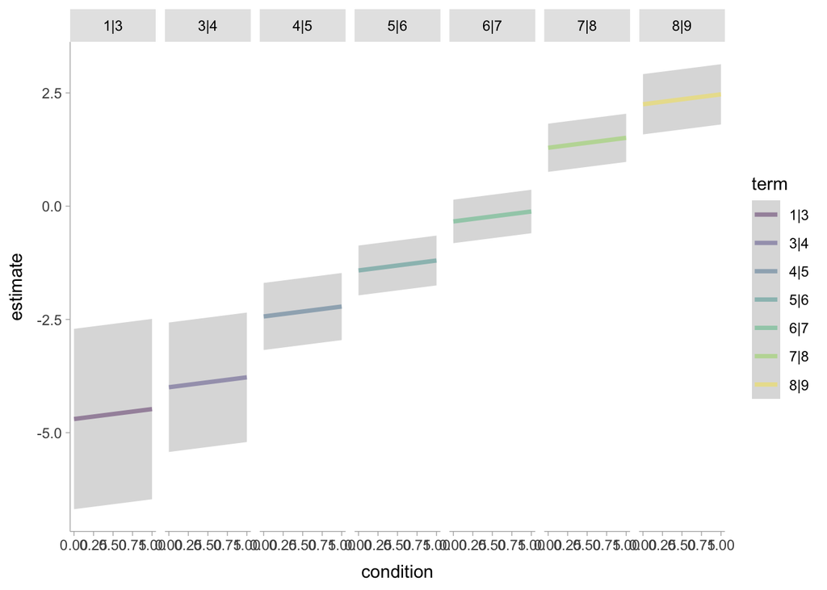

```r
tidy(m_olr_freq) %>%
  dplyr::slice(-n()) %>%
  crossing(condition = c("graph", "no_graph")) %>%
  mutate(estimate =
           ifelse(condition == "no_graph",
                  estimate + condition_no_graph$estimate,
                  estimate)) %>%
  mutate(.upper = estimate + 1.96 * std.error,
         .lower = estimate - 1.96 * std.error)  %>%
  mutate(condition = ifelse(condition == "graph", 0, 1)) %>%
  ggplot(aes(x = condition, y = estimate, group = term)) +
  facet_grid(~ term) + # EXERCISE: uncomment to see data better
  geom_lineribbon(aes(ymin = .lower, ymax = .upper, color = term), alpha = 0.4) +
  scale_color_viridis_d()
```

Going back to the data space… show predicted proportions and uncertainty

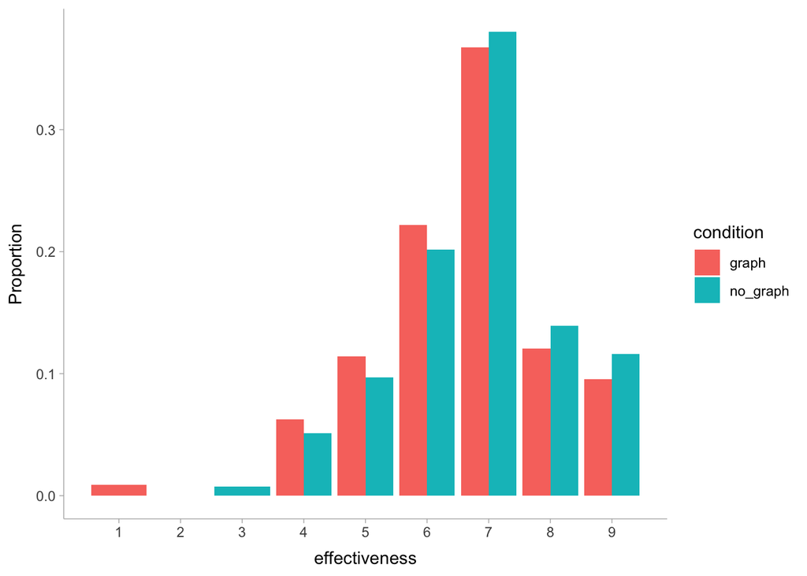

```r
# EXERCISE: how to show uncertainty with this?

as.data.frame(predict(m_olr_freq, type.predict = "prob", se.fit = TRUE)) %>%
  bind_cols(df1 %>% select(effectiveness, condition))  %>%
  group_by(effectiveness, condition) %>%
  slice_head() %>%
  ungroup()   %>%
  ggplot(aes(x = effectiveness, y = fit, fill = condition)) +
  geom_col(position = "dodge") +
  # geom_pointinterval(   # EXERCISE: put in the interval
  #   aes(ymin = fit - 1.96 * se.fit, ymax = fit + 1.96 * se.fit),
  #   position = "dodge") +
  scale_x_continuous(breaks = 1:9) +
  ylab("Proportion")
```

## Dataset 1, Bayesian land

### Dataset 1, Bayesian t-test

Load the model from last time….

```r
(m_t_test_bayesian <- readRDS("../02-bayesian_stats/rds/dataset1.brm.bayesiant.rds"))
```

```
##  Family: student
##   Links: mu = identity; sigma = identity; nu = identity
## Formula: effectiveness ~ condition - 1
##    Data: exp1.data (Number of observations: 123)
##   Draws: 4 chains, each with iter = 2000; warmup = 1000; thin = 1;
##          total post-warmup draws = 4000
##
## Population-Level Effects:
##                   Estimate Est.Error l-95% CI u-95% CI Rhat Bulk_ESS Tail_ESS
## conditiongraph        6.61      0.18     6.25     6.96 1.00     3840     2692
## conditionno_graph     6.77      0.17     6.43     7.11 1.00     3211     2355
##
## Family Specific Parameters:
##       Estimate Est.Error l-95% CI u-95% CI Rhat Bulk_ESS Tail_ESS
## sigma     1.30      0.11     1.07     1.52 1.00     3172     2490
## nu       16.84     11.62     4.36    46.74 1.00     3081     2832
##
## Draws were sampled using sampling(NUTS). For each parameter, Bulk_ESS
## and Tail_ESS are effective sample size measures, and Rhat is the potential
## scale reduction factor on split chains (at convergence, Rhat = 1).
```

Get estimates for parameters and outcome predictions (1..9).

```r
(grid_df1<- df1 %>%
  data_grid(condition, effectiveness)
)
```

```
## # A tibble: 16 × 2
##    condition effectiveness
##    <fct>             <dbl>
##  1 graph                 1
##  2 graph                 3
##  3 graph                 4
##  4 graph                 5
##  5 graph                 6
##  6 graph                 7
##  7 graph                 8
##  8 graph                 9
##  9 no_graph              1
## 10 no_graph              3
## 11 no_graph              4
## 12 no_graph              5
## 13 no_graph              6
## 14 no_graph              7
## 15 no_graph              8
## 16 no_graph              9
```

```r
(means_df1_t <- grid_df1 %>%
  add_epred_draws(m_t_test_bayesian, newdata = . ,dpar = TRUE))
```

```
## # A tibble: 64,000 × 10
## # Groups:   condition, effectiveness, .row [16]
##    condition effectiveness  .row .chain .iteration .draw .epred    mu sigma
##    <fct>             <dbl> <int>  <int>      <int> <int>  <dbl> <dbl> <dbl>
##  1 graph                 1     1     NA         NA     1   6.48  6.48  1.41
##  2 graph                 1     1     NA         NA     2   6.75  6.75  1.13
##  3 graph                 1     1     NA         NA     3   6.59  6.59  1.25
##  4 graph                 1     1     NA         NA     4   6.55  6.55  1.41
##  5 graph                 1     1     NA         NA     5   6.53  6.53  1.27
##  6 graph                 1     1     NA         NA     6   6.53  6.53  1.23
##  7 graph                 1     1     NA         NA     7   6.49  6.49  1.28
##  8 graph                 1     1     NA         NA     8   6.51  6.51  1.30
##  9 graph                 1     1     NA         NA     9   6.84  6.84  1.35
## 10 graph                 1     1     NA         NA    10   6.80  6.80  1.26
## # … with 63,990 more rows, and 1 more variable: nu <dbl>
```

```r
(preds_df1_t <- grid_df1 %>%
    add_predicted_draws(m_t_test_bayesian))
```

```
## # A tibble: 64,000 × 7
## # Groups:   condition, effectiveness, .row [16]
##    condition effectiveness  .row .chain .iteration .draw .prediction
##    <fct>             <dbl> <int>  <int>      <int> <int>       <dbl>
##  1 graph                 1     1     NA         NA     1        5.09
##  2 graph                 1     1     NA         NA     2        8.55
##  3 graph                 1     1     NA         NA     3        7.54
##  4 graph                 1     1     NA         NA     4        7.96
##  5 graph                 1     1     NA         NA     5        8.68
##  6 graph                 1     1     NA         NA     6        4.75
##  7 graph                 1     1     NA         NA     7        5.19
##  8 graph                 1     1     NA         NA     8        4.95
##  9 graph                 1     1     NA         NA     9        7.18
## 10 graph                 1     1     NA         NA    10        7.23
## # … with 63,990 more rows
```

Visualize parameter uncertainty, predictive uncertainty, and raw data.

EXERCISE:

- (which visual element?) <- Parameter uncertainty
- (which visual element?) <- Predictive uncertainty
- (which visual element?) <- Raw data (with intrinsic uncertainty, too!)

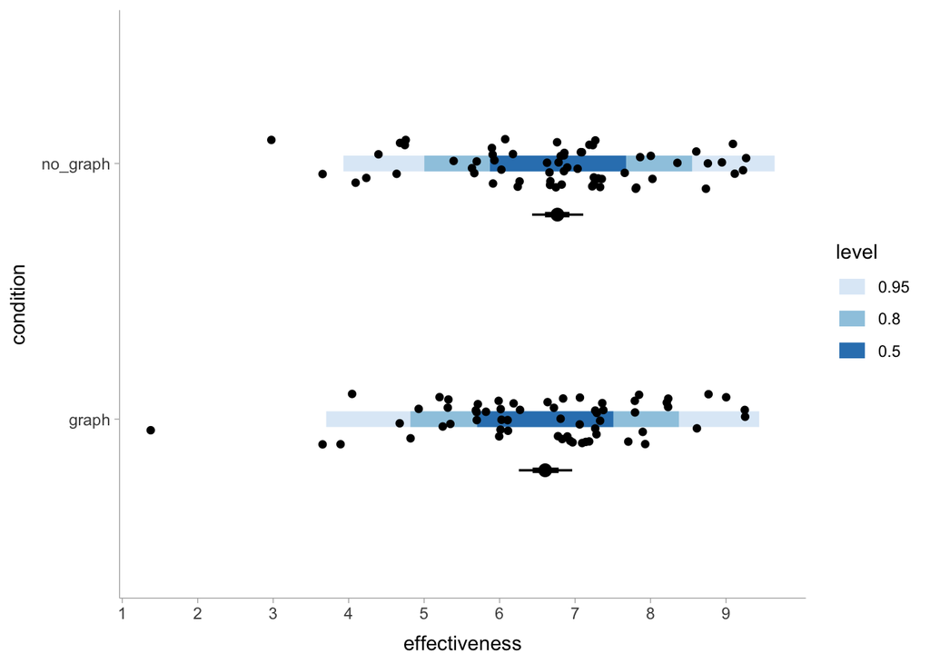

```r
df1 %>%
  ggplot(aes(x = effectiveness, y = condition)) +
  stat_interval(aes(x = .prediction), data = preds_df1_t) +

  # EXERCISE: change to density plot
  stat_pointinterval(aes(x = .epred), data = means_df1_t,
                     .width = c(.66, .95),
                     position = position_nudge(y = -0.2)) +
  geom_jitter(height = 0.1) +
  scale_x_continuous(breaks = 1:9)+
  scale_color_brewer()
```

An alternative way of seeing the uncertainty, in Kruschke style. The bunch of density lines shows both parameter and predictive uncertainty.

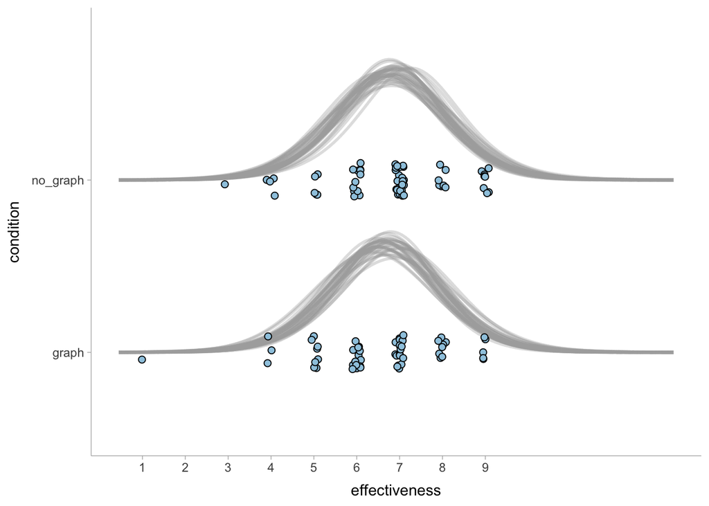

```r
means_df1_t %>%
  sample_draws(30) %>%
  ggplot(aes(y = condition)) +
  stat_slab(
    aes(xdist = dist_student_t(nu, mu, sigma)),
    slab_color="gray65", alpha = 0.05, fill = NA, scale = 0.7) +
  geom_jitter(aes(x = effectiveness), data = df1, shape = 21, fill = "#9ECAE1",  size = 2, width = 0.1, height = 0.1) +
  scale_x_continuous(breaks = 1:9)
```

```r
  NULL
```

### Dataset 1, Bayesian OLR

There’re starter values and stuff, not bothered just yet https://bookdown.org/ajkurz/Statistical_Rethinking_recoded/monsters-and-mixtures.html#ordered-categorical-outcomes

```r
(m_olr_bayes <- readRDS("../02-bayesian_stats/rds/dataset1.brm.olr1.rds"))
```

```
##  Family: cumulative
##   Links: mu = logit; disc = identity
## Formula: effectiveness ~ condition
##    Data: exp1.data (Number of observations: 123)
##   Draws: 4 chains, each with iter = 2000; warmup = 1000; thin = 1;
##          total post-warmup draws = 4000
##
## Population-Level Effects:
##                   Estimate Est.Error l-95% CI u-95% CI Rhat Bulk_ESS Tail_ESS
## Intercept[1]         -4.79      0.94    -6.96    -3.23 1.00     1762     1141
## Intercept[2]         -4.20      0.78    -5.98    -2.93 1.00     2466     1865
## Intercept[3]         -3.46      0.57    -4.71    -2.47 1.00     3340     2834
## Intercept[4]         -2.24      0.34    -2.97    -1.60 1.00     4238     3087
## Intercept[5]         -1.32      0.26    -1.83    -0.81 1.00     4691     3695
## Intercept[6]         -0.30      0.23    -0.74     0.17 1.00     4264     3276
## Intercept[7]          1.28      0.27     0.77     1.81 1.00     3594     3170
## Intercept[8]          2.26      0.34     1.63     2.96 1.00     3702     2956
## conditionno_graph     0.19      0.30    -0.38     0.78 1.00     4122     2809
##
## Family Specific Parameters:
##      Estimate Est.Error l-95% CI u-95% CI Rhat Bulk_ESS Tail_ESS
## disc     1.00      0.00     1.00     1.00   NA       NA       NA
##
## Draws were sampled using sampling(NUTS). For each parameter, Bulk_ESS
## and Tail_ESS are effective sample size measures, and Rhat is the potential
## scale reduction factor on split chains (at convergence, Rhat = 1).
```

Get posterior estimates for the parameters and predictions (outcome on the scale of 1…9)

```r
(means_df1_olr <- expand(df1, condition) %>%
  add_epred_draws(m_olr_bayes, dpar = TRUE) %>%
   rename(effectiveness = .category)
)
```

```
## # A tibble: 72,000 × 9
## # Groups:   condition, .row, effectiveness [18]
##    condition  .row .chain .iteration .draw effectiveness  .epred    mu  disc
##    <fct>     <int>  <int>      <int> <int> <fct>           <dbl> <dbl> <dbl>
##  1 graph         1     NA         NA     1 1             0.0124    0.5     1
##  2 graph         1     NA         NA     2 1             0.0116    0.5     1
##  3 graph         1     NA         NA     3 1             0.0185    0.5     1
##  4 graph         1     NA         NA     4 1             0.0335    0.5     1
##  5 graph         1     NA         NA     5 1             0.0219    0.5     1
##  6 graph         1     NA         NA     6 1             0.00192   0.5     1
##  7 graph         1     NA         NA     7 1             0.0145    0.5     1
##  8 graph         1     NA         NA     8 1             0.00389   0.5     1
##  9 graph         1     NA         NA     9 1             0.0137    0.5     1
## 10 graph         1     NA         NA    10 1             0.00495   0.5     1
## # … with 71,990 more rows
```

```r
(preds_df1_olr <- expand(df1, condition) %>%
    add_predicted_draws(m_olr_bayes) %>%
    select(-c(.chain, .iteration)) %>%
   drop_na()
 )
```

```
## # A tibble: 7,122 × 4
## # Groups:   condition, .row [2]
##    condition  .row .draw .prediction
##    <fct>     <int> <int> <fct>
##  1 graph         1     1 7
##  2 graph         1     2 8
##  3 graph         1     3 7
##  4 graph         1     4 8
##  5 graph         1     5 9
##  6 graph         1     6 8
##  7 graph         1     8 8
##  8 graph         1     9 8
##  9 graph         1    11 5
## 10 graph         1    12 8
## # … with 7,112 more rows
```

EXERCISE: why does this look different from the frequentist version?

```r
(df1_prop <- df1 %>%
  count(condition, effectiveness) %>%
  group_by(condition) %>%
  mutate(prop = n/sum(n))
)
```

```
## # A tibble: 14 × 4
## # Groups:   condition [2]
##    condition effectiveness     n   prop
##    <fct>             <dbl> <int>  <dbl>
##  1 graph                 1     1 0.0164
##  2 graph                 4     3 0.0492
##  3 graph                 5     8 0.131
##  4 graph                 6    14 0.230
##  5 graph                 7    21 0.344
##  6 graph                 8     9 0.148
##  7 graph                 9     5 0.0820
##  8 no_graph              3     1 0.0161
##  9 no_graph              4     4 0.0645
## 10 no_graph              5     5 0.0806
## 11 no_graph              6    12 0.194
## 12 no_graph              7    25 0.403
## 13 no_graph              8     7 0.113
## 14 no_graph              9     8 0.129
```

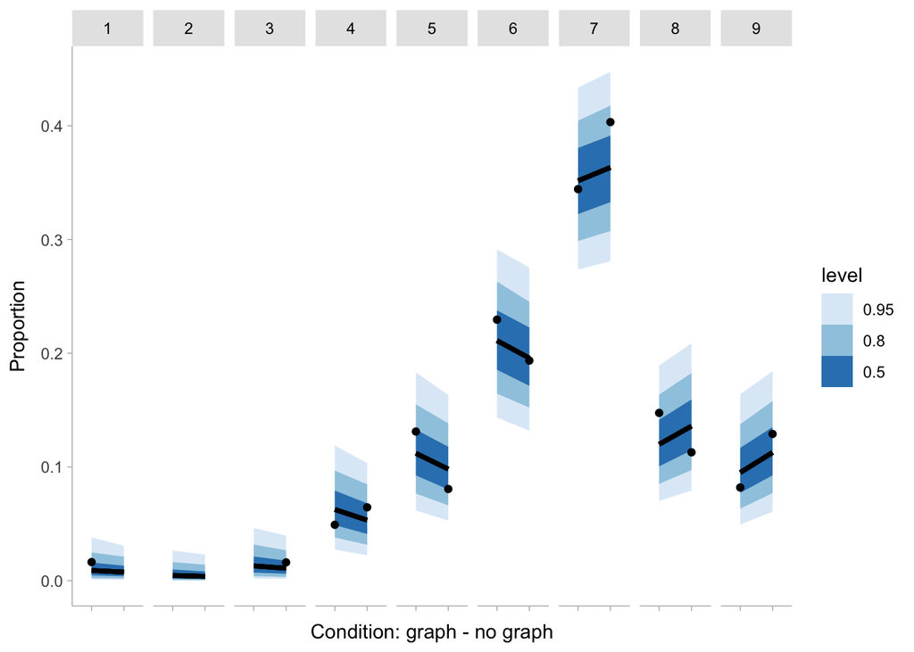

```r
means_df1_olr %>%
  ggplot(aes(x = condition, y = .epred)) +
  stat_lineribbon()  +
  geom_point(aes(x = condition, y = prop), data = df1_prop) +
  scale_fill_brewer() +
  facet_grid(~ effectiveness) +
  theme(axis.text.x = element_blank()) +
  xlab("Condition: graph - no graph") +
  ylab("Proportion")
```

EXERCISE (challenge): follow https://bookdown.org/ajkurz/Statistical_Rethinking_recoded/monsters-and-mixtures.html#ordered-categorical-outcomes to construct a stacked version

```r
(means_df1_olr_compare <- means_df1_olr %>%
  group_by(effectiveness) %>%
  compare_levels(variable = .epred, by = condition )
)
```

```
## # A tibble: 36,000 × 6
## # Groups:   effectiveness, condition [9]
##    effectiveness .chain .iteration .draw condition            .epred
##    <fct>          <int>      <int> <int> <chr>                 <dbl>
##  1 1                 NA         NA     1 no_graph - graph  0.00340
##  2 1                 NA         NA     2 no_graph - graph -0.00469
##  3 1                 NA         NA     3 no_graph - graph -0.00505
##  4 1                 NA         NA     4 no_graph - graph -0.00109
##  5 1                 NA         NA     5 no_graph - graph -0.00582
##  6 1                 NA         NA     6 no_graph - graph  0.0000320
##  7 1                 NA         NA     7 no_graph - graph -0.00412
##  8 1                 NA         NA     8 no_graph - graph -0.00110
##  9 1                 NA         NA     9 no_graph - graph -0.00410
## 10 1                 NA         NA    10 no_graph - graph -0.00106
## # … with 35,990 more rows
```

```r
(df1_prop_diff <- df1_prop %>%
  pivot_wider(id_col = effectiveness, names_from = condition, values_from = prop) %>%
  drop_na() %>%
  mutate(diff = no_graph - graph)
)
```

```
## # A tibble: 6 × 4
##   effectiveness  graph no_graph    diff
##           <dbl>  <dbl>    <dbl>   <dbl>
## 1             4 0.0492   0.0645  0.0153
## 2             5 0.131    0.0806 -0.0505
## 3             6 0.230    0.194  -0.0360
## 4             7 0.344    0.403   0.0590
## 5             8 0.148    0.113  -0.0346
## 6             9 0.0820   0.129   0.0471
```

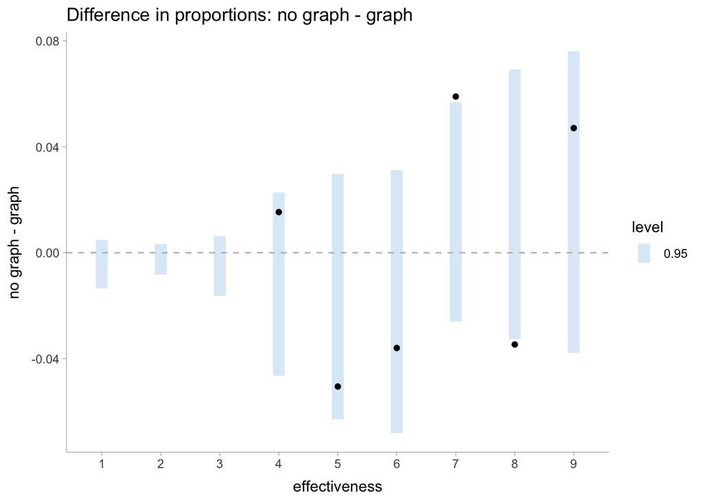

```r
means_df1_olr_compare %>%
  ggplot(aes(x = effectiveness, y = .epred)) +
  stat_interval(.width = c(0.95)) +  # EXERCISE: can you be more expressive with uncertainty?
  geom_hline(                        # EXERCISE: add reference line y = 0
    yintercept = 0, linetype = "dashed", color = "grey") +
  geom_point(aes(y = diff), data= df1_prop_diff) +  #EXERCISE: add raw data
  scale_color_brewer() +
  ylab("no graph - graph") +
  labs(title = "Difference in proportions: no graph - graph") +
  NULL
```

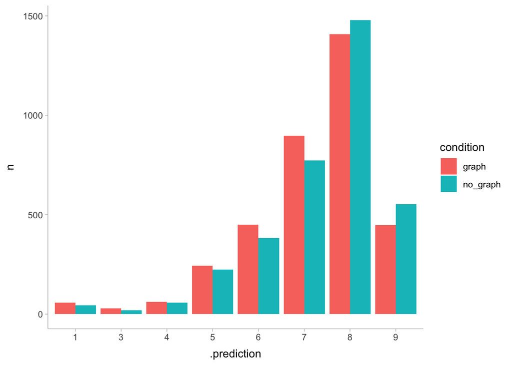

```r
preds_df1_olr %>%
  count(condition, .prediction) %>%
  ggplot(aes(.prediction, n, fill = condition)) +
  geom_col(position = "dodge")
```

## Dataset 2 Power Pose

Load the dataframe. Data dictionary/column description at https://github.com/yvonnejansen/posture/blob/master/data/exp2_column-description.csv

```r
df2 <- read_csv("../02-bayesian_stats/data/exp2.csv")
```

We only modeled two variables: `change` and `condition`.

```r
df2 %>%
  group_by(condition) %>%
  count()
```

```
## # A tibble: 2 × 2
## # Groups:   condition [2]
##   condition        n
##   <chr>        <int>
## 1 constrictive    40
## 2 expansive       40
```

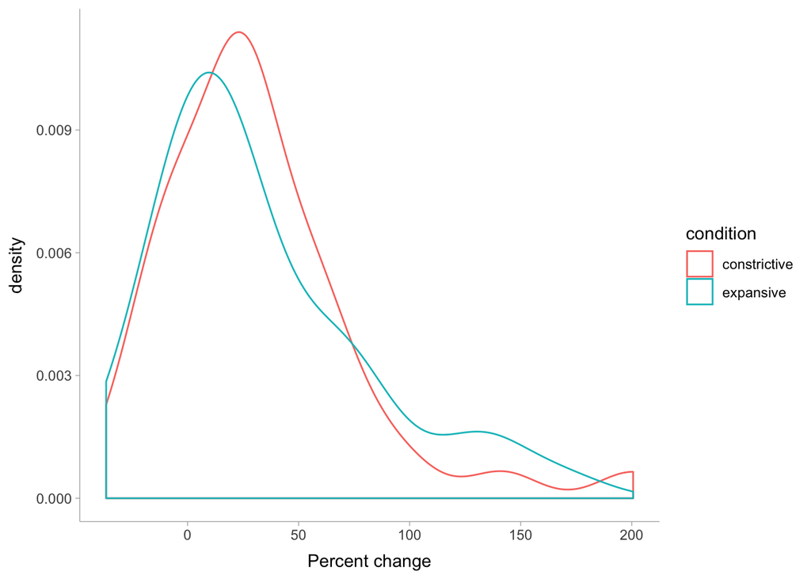

```r
df2 %>%
  ggplot(aes(x = change, color = condition)) +
  # geom_dots( alpha = 0.4) +
  geom_density(outline.type = "full") +
  xlab("Percent change") +
  NULL
```

## Dataset 2 results

```r
if (!file.exists("data/dataset2.brm.student.rds")){
fit.brm <- brm(
   bf(
    change ~ condition, sigma ~ condition,
    family = student()
  ),
  prior = c(
    prior(normal(0, 2), class = "b"),
    prior(cauchy(0, 2), class = "b", dpar = "sigma"),
    prior(exponential(0.03), class = "nu"),
    prior(student_t(3, 0, 5), class = "Intercept"),
    prior(student_t(3, 0, 2), class = "Intercept", dpar = "sigma")
  ),
  data = df2,
  seed = 99, chains = 4, cores = 4,
  file = "data/dataset2.brm.student.rds")
} else {
  fit.brm <- readRDS("data/dataset2.brm.student.rds")
}

fit.brm
```

```
##  Family: student
##   Links: mu = identity; sigma = log; nu = identity
## Formula: change ~ condition
##          sigma ~ condition
##    Data: df2 (Number of observations: 80)
##   Draws: 4 chains, each with iter = 2000; warmup = 1000; thin = 1;
##          total post-warmup draws = 4000
##
## Population-Level Effects:
##                          Estimate Est.Error l-95% CI u-95% CI Rhat Bulk_ESS
## Intercept                   20.97      4.81    12.01    30.99 1.00     2786
## sigma_Intercept              3.37      0.19     2.99     3.75 1.00     2599
## conditionexpansive          -0.21      1.95    -4.11     3.65 1.00     3977
## sigma_conditionexpansive     0.13      0.22    -0.30     0.57 1.00     3571
##                          Tail_ESS
## Intercept                    2242
## sigma_Intercept              2684
## conditionexpansive           3061
## sigma_conditionexpansive     2515
##
## Family Specific Parameters:
##    Estimate Est.Error l-95% CI u-95% CI Rhat Bulk_ESS Tail_ESS
## nu     4.52      4.40     1.65    14.68 1.00     1986     1625
##
## Draws were sampled using sampling(NUTS). For each parameter, Bulk_ESS
## and Tail_ESS are effective sample size measures, and Rhat is the potential
## scale reduction factor on split chains (at convergence, Rhat = 1).
```

```r
get_variables(fit.brm)
```

```
##  [1] "b_Intercept"                "b_sigma_Intercept"
##  [3] "b_conditionexpansive"       "b_sigma_conditionexpansive"
##  [5] "nu"                         "lp__"
##  [7] "accept_stat__"              "stepsize__"
##  [9] "treedepth__"                "n_leapfrog__"
## [11] "divergent__"                "energy__"
```

```r
(grid <- df2 %>% data_grid(condition))
```

```
## # A tibble: 2 × 1
##   condition
##   <chr>
## 1 constrictive
## 2 expansive
```

```r
(means <- grid %>%
  add_epred_draws(fit.brm, dpar = TRUE)
  )
```

```
## # A tibble: 8,000 × 9
## # Groups:   condition, .row [2]
##    condition     .row .chain .iteration .draw .epred    mu sigma    nu
##    <chr>        <int>  <int>      <int> <int>  <dbl> <dbl> <dbl> <dbl>
##  1 constrictive     1     NA         NA     1   22.4  22.4  30.2  3.88
##  2 constrictive     1     NA         NA     2   22.8  22.8  26.5  5.96
##  3 constrictive     1     NA         NA     3   19.7  19.7  24.5  6.19
##  4 constrictive     1     NA         NA     4   23.2  23.2  22.3  4.66
##  5 constrictive     1     NA         NA     5   14.6  14.6  33.4  2.25
##  6 constrictive     1     NA         NA     6   14.6  14.6  30.9  4.04
##  7 constrictive     1     NA         NA     7   28.7  28.7  28.3  3.09
##  8 constrictive     1     NA         NA     8   29.0  29.0  27.5  2.68
##  9 constrictive     1     NA         NA     9   13.1  13.1  35.9  1.77
## 10 constrictive     1     NA         NA    10   18.3  18.3  25.6  4.01
## # … with 7,990 more rows
```

```r
(preds <- grid %>%
  add_predicted_draws(fit.brm)
)
```

```
## # A tibble: 8,000 × 6
## # Groups:   condition, .row [2]
##    condition     .row .chain .iteration .draw .prediction
##    <chr>        <int>  <int>      <int> <int>       <dbl>
##  1 constrictive     1     NA         NA     1      -17.9
##  2 constrictive     1     NA         NA     2       48.3
##  3 constrictive     1     NA         NA     3       18.1
##  4 constrictive     1     NA         NA     4      104.
##  5 constrictive     1     NA         NA     5        2.43
##  6 constrictive     1     NA         NA     6       34.4
##  7 constrictive     1     NA         NA     7       40.5
##  8 constrictive     1     NA         NA     8       47.0
##  9 constrictive     1     NA         NA     9       47.9
## 10 constrictive     1     NA         NA    10       64.4
## # … with 7,990 more rows
```

```r
df2_range <- c(min(df2$change - 20), max(df2$change + 20))
```

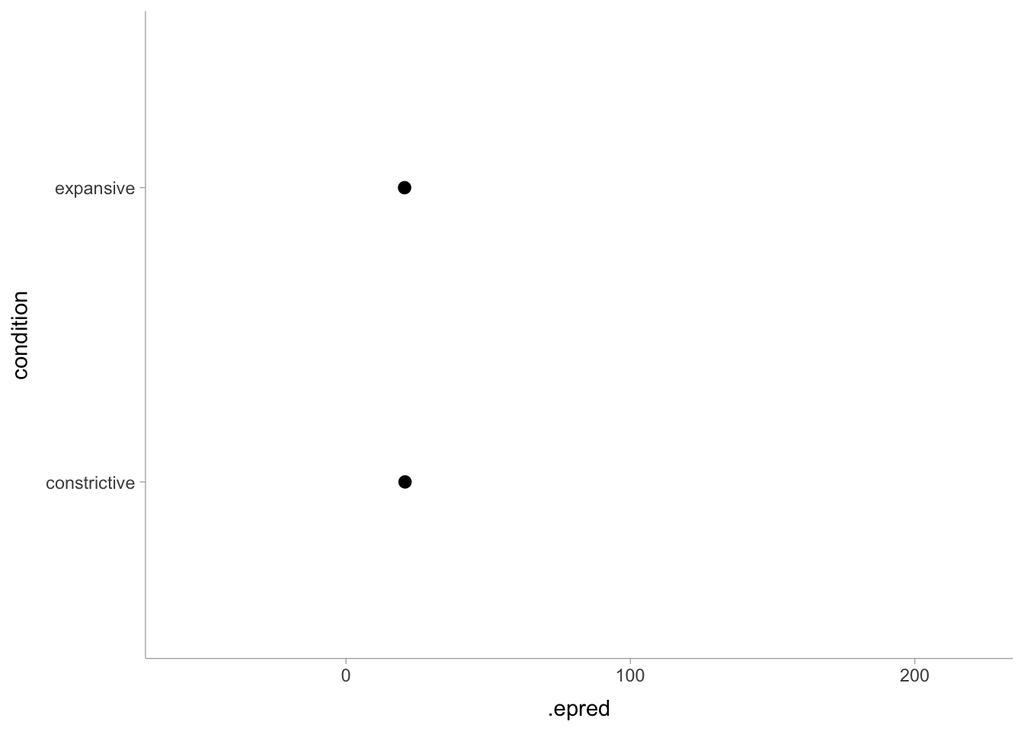

```r
means %>%
  ggplot(aes(x = .epred, y = condition)) +
  stat_pointinterval(.width = 0)+
  xlim(df2_range)
```

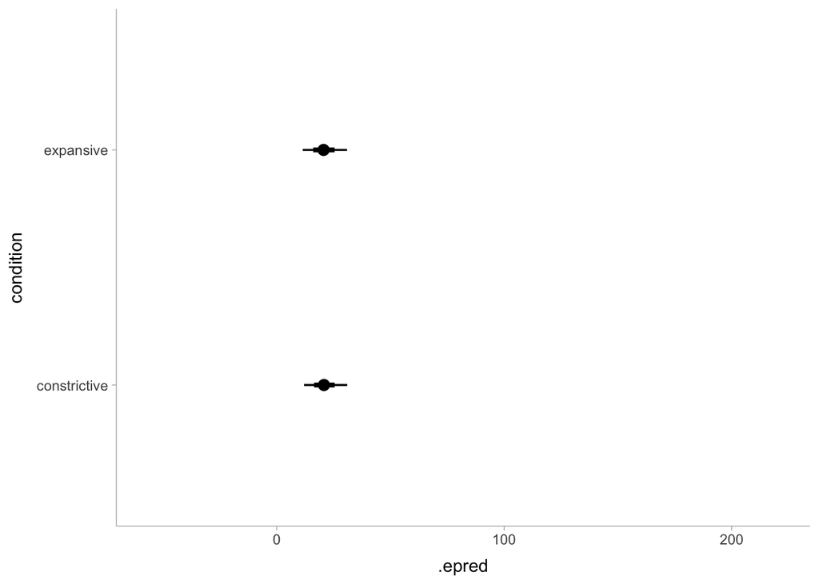

```r
means %>%
  ggplot(aes(x = .epred, y = condition)) +
  stat_pointinterval() +
  xlim(df2_range)
```

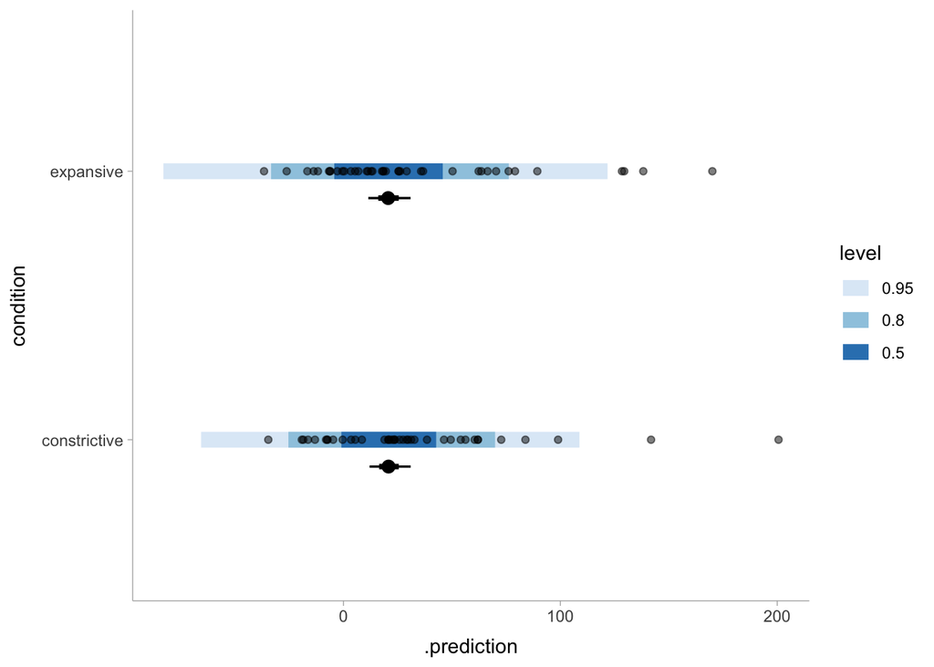

```r
ggplot() +
  stat_interval(
    aes(x = .prediction, y = condition),
    data = preds) +
  geom_point(aes(x = change, y = condition), data = df2, alpha = .5) +
  # stat_dots(
  #   aes(x = change, y = condition),
  #   data = df2, alpha = 0.5, position = position_nudge(y = 0.1) , scale = 0.8) +
  stat_pointinterval(
    aes(x = .epred, y = condition),
    data = means, position = position_nudge(y = -0.1)) +
  scale_color_brewer()
```

(Reflection: think about what these all mean)

- How wide are the intervals?

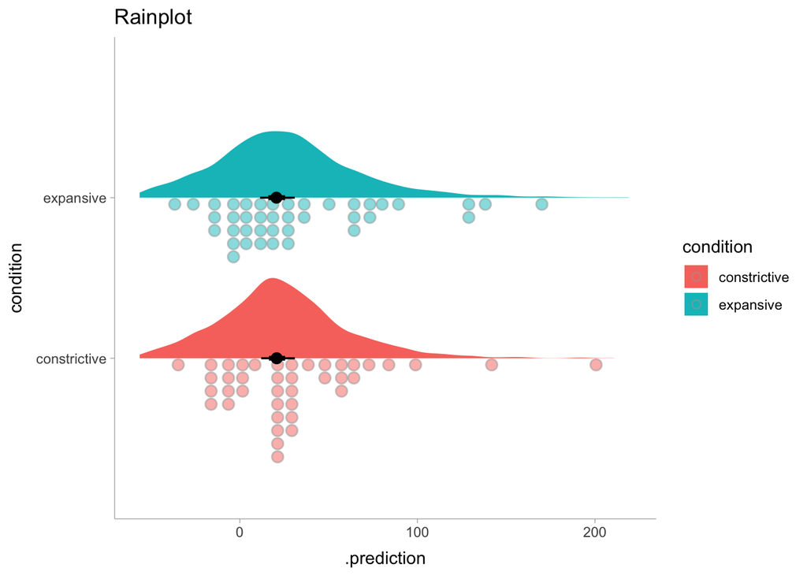

```r
ggplot(mapping = aes(fill = condition)) +
  stat_slab(
    aes(x = .prediction, y = condition, thickness = stat(pdf * n)),
    data = preds, scale = 0.5) +
  stat_dots(
    aes(x = change, y = condition, side = "bottom"),
    data = df2, alpha = 0.5, scale = 0.7) +
  stat_pointinterval(
    aes(x = .epred, y = condition),
    data = means) +
  labs(title = "Rainplot") +
  xlim(df2_range)
```

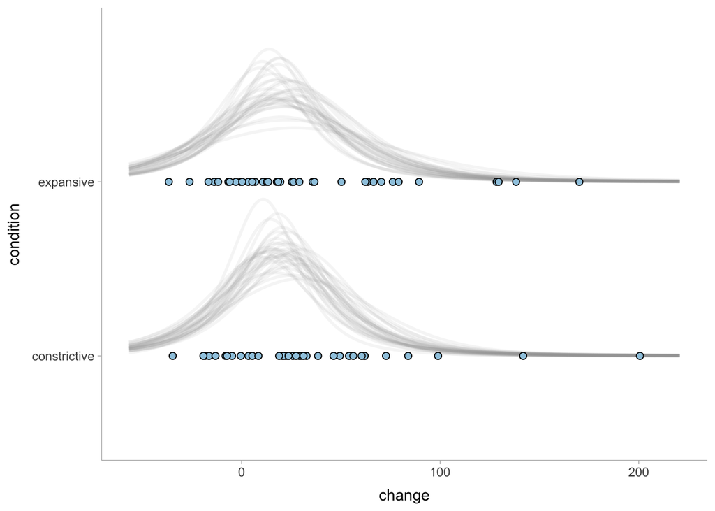

```r
means %>%
  sample_draws(30) %>%
  ggplot(aes(y = condition)) +
  stat_slab(aes(xdist = dist_student_t(nu, mu, sigma)),
                 slab_color="gray65", alpha = 0.1, fill = NA) +
  geom_point(aes(x = change), data = df2, shape = 21, fill = "#9ECAE1",  size = 2) +
  xlim(df2_range) +
  NULL
```